# Homework 12 - Command Line Interfaces

Author

Prakash Chatlani

Published

April 16, 2024

Homework 12 serves up three different command line interface programs. We’re using python and the click library to create beautiful user interfaces. You get to decide what your program does.

- [LINK to repo for HW12](https://github.com/cmsc-vcu/cmsc475-sp2024-hw12-prakashhc)

# CLI 1 - Convert Currency

This program allows the user to convert currency values from one currency to another.

## Key features

- defaults to USD if not specified by the user
- can change the source country with ‘–from’
- can change the destination country with ‘–to’
- can change the amount with ‘-ammount’

## App documentation

### Example command: Default usage

```
convertCurrency --amount 1 --to INR
1.0 USD is equal to 83.51 INR
```

### Example command: more complicated example

```
convertCurrency --from EUR --to USD --amount 100
100.0 EUR is equal to 106.00 USD
```

## Sample screens

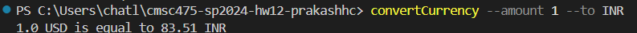

# CLI 2 - Weather

This program allows the user to see the weather.

## Key features

- defaults to zip code of 23059
- can change the zip code and see different weathers with ‘–zip’ option

## App documentation

### Example command: Default usage

```
weather
Current weather for Glen Allen, Virginia, USA:
- Temperature: 62.1°F (16.7°C)
- Conditions: Fog
- Wind: 2.2 mph (3.6 kph) from N
- Humidity: 96%
```

### Example command: more complicated example

```
weather --zip 60514
Current weather for Clarendon Hills, Illinois, USA:
- Temperature: 57.0°F (13.9°C)
- Conditions: Partly cloudy
- Wind: 10.5 mph (16.9 kph) from E
- Humidity: 45%
```

## Sample screens

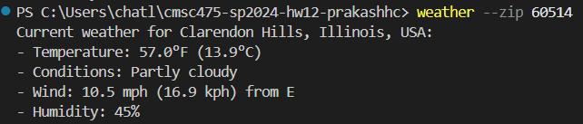

# CLI 3 - inchesToFeet

This program allows the user to convert a certain number of inches into feet

## Key features

- can change the number of inches by using ‘–inches’

## App documentation

### Example command: Default usage

```
inchesToFeet --inches 13
13.0 inches is equal to 1 feet and 1.00 inches.
```

## Sample screens

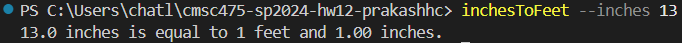

# Reflection

- Should this module be taught at the beginning or the end of the semester? That is, would these skills have helped you with capstone had you know them earlier? I think that this assignment was appropriate in its current place. It allows me to finish mobile development during a time when I wasn’t very stressed out, and allowed for an easy transition towards the end of the semester. I am not taking not currently taking capstone, so I cannot answer.
- How much time did you spend on this specific assignment? I spent about three hours on this assignment.
- What was the easiest part of this specific assignment? The easiest part of the assignment was getting the API keys and finding the sources for currency exchange rates and weather.
- What is the hardest part of this specific assignment? The hardest part of the assignment was writing the python code for associating the APIs with the variables.